# GBSV MC2 – Segmentation

Autor:in

Luca Manna

Veröffentlichungsdatum

14. Mai 2026

# 1 Aufgabe: Segmentation

**Land:** USA  
**Semester:** FS26

## 1.1 Tag 11 – Daten & Domäne

### 1.1.1 Anwendungsfall

Das Kartenspiel SET wurde 1974 von Marsha Falco in den USA entwickelt und wird heute durch Set Enterprises (Fountain Hills, Arizona) weltweit vertrieben. Auf dem Tisch liegen 12 Karten in einer regulären Auslage; alle Spielenden suchen gleichzeitig nach einer gültigen Dreierkombination über vier Eigenschaften: Menge (1, 2 oder 3 Symbole), Farbe (rot, violett, grün), Form (Raute, Balken, Welle) und Füllung (leer, halb, voll).

Das langfristige Ziel ist eine Bildverarbeitungs-Pipeline, die aus einem Smartphone-Foto der Auslage automatisch das nächste gültige SET vorschlägt. Pattern Detection (Tags 6-10) hat die Kartenränder per Canny-Algorithmus lokalisiert. Der nächste Verarbeitungsschritt ist die Analyse der Symbole innerhalb jeder Karte: die Eigenschaft “Menge” ergibt sich direkt aus der Anzahl der segmentierten Objekte pro Karte; geometrische Messgrössen der isolierten Symbole liefern Hinweise auf Form und Füllung. Segmentierung ist die geeignete Methode, um diese Symbole vom weissen Kartenhintergrund zu trennen und als separate Objekte zugänglich zu machen.

Persönliche Motivation: Ich verliere beim SET-Spielen regelmässig gegen meine Freundin und möchte das mit einem automatischen Hilfssystem ausgleichen.

### 1.1.2 Problemstellung

Die Symbole auf SET-Karten (Raute, Balken, Welle; rot, violett, grün; leer, halb, voll gefüllt) sind auf einer weissen Kartenfläche gedruckt. Der Intensitätskontrast zwischen farbigen Symbolen und weissem Hintergrund ist der zentrale Anhaltspunkt für eine schwellenwertbasierte Segmentierung. Drei Schwierigkeiten treten in realen Smartphone-Aufnahmen auf:

1. **Beleuchtungsvariation:** Glanzlichter auf glänzenden Kartenflächen können Symbole lokal aufhellen und den Kontrast zum Hintergrund reduzieren.
2. **Halbgefüllte Symbole:** Symbole mit Füllung “halb” zeigen einen schraffierten Innenbereich, dessen Intensität zwischen dem Symbolrand und dem weissen Hintergrund liegt. Ein globaler Schwellenwert kann diesen Bereich falsch klassifizieren.
3. **Karte-zu-Karte-Variation:** Helligkeit und Farbsättigung der Symbole variieren je nach Lichteinfall und Druckqualität zwischen einzelnen Karten.

Die Segmentierung muss unter diesen Bedingungen die Symbole eines repräsentativen Kartenausschnitts zuverlässig vom Hintergrund trennen, sodass eine korrekte Symbolzählung und Objektmessung möglich ist.

### 1.1.3 Datendefinition, Quelle und Visualisierung

Das Referenzbild ist eine eigene Smartphone-Aufnahme einer regulären SET-Auslage (`mc2/data/IMG_6947.JPG`, 4032 x 3024 Pixel, RGB, JPG-komprimiert). Es zeigt 12 Karten in einer Anordnung mit 4 Zeilen und 3 Spalten auf einer dunkelgrünen Spielmatte.

Die Symbole besitzen folgende visuelle Charakteristika: - **Intensität:** farbige Symbole erscheinen deutlich dunkler als der weisse Kartenhintergrund; die Intensitätsdifferenz beträgt typischerweise 80-180 Graustufen. - **Kontrast:** hoher Farbkontrast auf RGB-Ebene zwischen gesättigten Symbolen (rot, violett, grün) und dem nahezu achromatischen weissen Hintergrund. - **Form:** kompakte, konvexe oder geschwungene Umrisse; Raute und Balken haben gerade Kanten, Welle zeigt eine geschwungene S-Kontur. - **Überlappung:** keine direkte Überlappung zwischen den Symbolen auf einer Karte; Symbole sind durch einen weissen Zwischenraum getrennt.

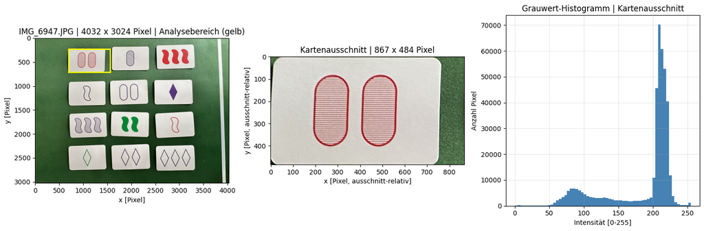

```
Ausschnitt: 867 x 484 Pixel | Intensitätsbereich: [1, 255] | Mittelwert: 185.9
```

```python
from pathlib import Path
import numpy as np
import matplotlib.pyplot as plt
from PIL import Image
from matplotlib.patches import Rectangle

IMG_PATH = Path("..") / "data" / "IMG_6947.JPG"
img_pil = Image.open(IMG_PATH)
img = np.array(img_pil)
img_gray = np.array(img_pil.convert("L"))
H, W = img.shape[:2]

# Repräsentativer Kartenausschnitt: obere linke Karte (Koordinaten aus Helligkeitsprofil ermittelt)
y0, y1 = int(0.074 * H), int(0.234 * H)
x0, x1 = int(0.173 * W), int(0.388 * W)
card_crop = img[y0:y1, x0:x1]
card_gray = img_gray[y0:y1, x0:x1]

fig, axes = plt.subplots(1, 3, figsize=(15, 5))

axes[0].imshow(img)
rect = Rectangle(
    (x0, y0), x1 - x0, y1 - y0, linewidth=2, edgecolor="yellow", facecolor="none"
)
axes[0].add_patch(rect)
axes[0].set_title(f"IMG_6947.JPG | {W} x {H} Pixel | Analysebereich (gelb)")
axes[0].set_xlabel("x [Pixel]")
axes[0].set_ylabel("y [Pixel]")

axes[1].imshow(card_crop)
axes[1].set_title(f"Kartenausschnitt | {x1 - x0} x {y1 - y0} Pixel")
axes[1].set_xlabel("x [Pixel, ausschnitt-relativ]")
axes[1].set_ylabel("y [Pixel, ausschnitt-relativ]")

axes[2].hist(
    card_gray.ravel(), bins=64, range=(0, 255), color="steelblue", edgecolor="none"
)
axes[2].set_title("Grauwert-Histogramm | Kartenausschnitt")
axes[2].set_xlabel("Intensität [0-255]")
axes[2].set_ylabel("Anzahl Pixel")
axes[2].grid(True, alpha=0.3)

plt.tight_layout()
plt.show()

print(
    f"Ausschnitt: {x1 - x0} x {y1 - y0} Pixel "
    f"| Intensitätsbereich: [{card_gray.min()}, {card_gray.max()}] "
    f"| Mittelwert: {card_gray.mean():.1f}"
)
```

**Beobachtungen:**

Der Kartenausschnitt zeigt farbige Symbole auf überwiegend weissem Hintergrund. Das Grauwert-Histogramm zeigt eine klare Zweiteilung: eine dominante Häufung bei hohen Intensitätswerten (ca. 200-255, weisser Kartenhintergrund, ~72 % der Pixel) und ein breiteres Cluster im dunklen bis mittleren Bereich (ca. 50-150, Symbol- und Randpixel des Kartenausschnitts, ~22 % der Pixel). Der deutliche Intensitätsunterschied zwischen diesen Bereichen bestätigt, dass eine schwellenwertbasierte Trennung der Symbole vom Hintergrund prinzipiell möglich ist. Die genaue Lage des geeigneten Schwellenwerts wird in Tag 12 bestimmt.

### 1.1.4 Objektdefinition

Ein Objekt entspricht einem einzelnen Symbol auf einer SET-Karte. Symbole sind kompakte, zusammenhängende Regionen (Connected Components), die sich durch ihre Intensität und Farbe vom weissen Kartenhintergrund abheben. Ein Symbol belegt typischerweise 5-20 % der Kartenfläche, besitzt eine klar definierte Aussenkontur und ist von anderen Symbolen auf derselben Karte durch einen weissen Zwischenraum getrennt.

### 1.1.5 Segmentierungsziel

Das Ziel der Segmentierung ist die automatische Trennung der Symbole vom weissen Kartenhintergrund im gewählten Kartenausschnitt. Die Segmentierung soll:

1. **Zählen:** Anzahl der isolierten Symbole bestimmen (Karteneigenschaft “Menge”: 1, 2 oder 3).
2. **Vermessen:** Geometrische Eigenschaften jedes Symbols extrahieren (z.B. Fläche, Umfang, Ausdehnung).
3. **Vorbereiten:** Eine binäre Maske liefern, die als Grundlage für morphologische Operationen und die Skeletonization eines ausgewählten Symbols (Tag 13) dient.

Die Segmentierung basiert ausschliesslich auf der Intensitäts- und Farbinformation des Bildausschnitts, ohne geometrisches Vorwissen über Symbolform oder -lage.

## 1.2 Tag 12 – Methodisches Design

Tag 12 legt das methodische Fundament für die Implementierung an Tag 13. Die folgenden Abschnitte begründen die Wahl der Schwellenwertmethode, der morphologischen Operationen, des Skeletonisierungsziels und der Objekteigenschaften. Abschliessend werden drei Konfigurationen (Baseline + 2 Variationen) definiert, die an Tag 14 quantitativ verglichen werden.

### 1.2.1 Schwellenwertmethode

**Methode:** Otsu-Schwellenwert (globaler automatischer Threshold, `skimage.filters.threshold_otsu`).

**Begründung:** Das Grauwert-Histogramm des Kartenausschnitts zeigt eine bimodale Verteilung (nachgewiesen an Tag 11): ein hohes Peak bei ca. 200-255 (weisser Hintergrund) und ein breiteres Cluster bei ca. 50-150 (Symbolpixel). Otsu minimiert die gewichtete Intra-Klassen-Varianz und findet automatisch den optimalen Trennwert zwischen den beiden Klassen – ohne manuellen Parameter.

Eine adaptive Schwellenwertmethode (lokale Fenster) wäre nur notwendig, wenn die Beleuchtung innerhalb des Kartenausschnitts stark variiert. Der gewählte Ausschnitt zeigt keine starken Glanzlichter, weshalb der globale Otsu-Wert ausreichend ist.

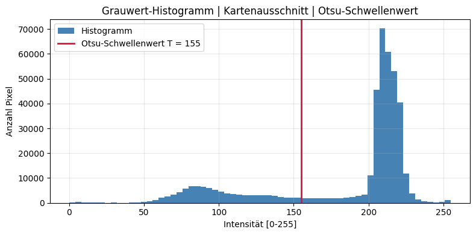

```
Otsu-Schwellenwert: T = 155
Vordergrund (< T): 22.5% | Hintergrund (>= T): 77.5%
```

```python
from pathlib import Path
import numpy as np
import matplotlib.pyplot as plt
from PIL import Image
from skimage.filters import threshold_otsu

IMG_PATH = Path("..") / "data" / "IMG_6947.JPG"
img_pil = Image.open(IMG_PATH)
img_gray = np.array(img_pil.convert("L"))
H, W = img_gray.shape

y0, y1 = int(0.074 * H), int(0.234 * H)
x0, x1 = int(0.173 * W), int(0.388 * W)
card_gray = img_gray[y0:y1, x0:x1]

t_otsu = threshold_otsu(card_gray)

fig, ax = plt.subplots(figsize=(8, 4))
ax.hist(
    card_gray.ravel(),
    bins=64,
    range=(0, 255),
    color="steelblue",
    edgecolor="none",
    label="Histogramm",
)
ax.axvline(
    t_otsu, color="crimson", linewidth=2, label=f"Otsu-Schwellenwert T = {t_otsu}"
)
ax.set_title("Grauwert-Histogramm | Kartenausschnitt | Otsu-Schwellenwert")
ax.set_xlabel("Intensität [0-255]")
ax.set_ylabel("Anzahl Pixel")
ax.legend()
ax.grid(True, alpha=0.3)
plt.tight_layout()
plt.show()

pct_fg = (card_gray < t_otsu).mean() * 100
pct_bg = (card_gray >= t_otsu).mean() * 100
print(f"Otsu-Schwellenwert: T = {t_otsu}")
print(f"Vordergrund (< T): {pct_fg:.1f}% | Hintergrund (>= T): {pct_bg:.1f}%")
```

### 1.2.2 Morphologische Operationen

Nach der Binarisierung enthält die binäre Maske zwei Arten von Artefakten:

1. **Rauschen (kleine isolierte Vordergrundpixel):** JPEG-Kompressionsartefakte und feine Drucktexturen erzeugen vereinzelte Pixel, die irrtümlicherweise als Vordergrund klassifiziert werden.
2. **Löcher in Symbolen:** Symbole mit Füllung “halb” besitzen einen schraffierten Innenbereich, dessen Intensität nahe dem Schwellenwert liegt. Einzelne Innenpixel können als Hintergrund klassifiziert werden.

**Verarbeitungssequenz:**

1. **Opening** (Erosion gefolgt von Dilation, Disk-Kernel Radius r): entfernt kleine Rauschpixel ohne die Symbolränder stark zu verändern. Ein Disk-Kernel bewahrt runde Konturformen besser als ein quadratischer Kernel.
2. **Filterung nach Mindestfläche** (`min_area_px`): entfernt verbleibende Kleinstkomponenten nach dem Opening.
3. **Closing** (Dilation gefolgt von Erosion, Disk-Kernel Radius r): schliesst kleine Lücken innerhalb der Symbolregionen; relevant für “halb”-gefüllte Symbole.

Kernel-Radius und die Entscheidung, ob Closing angewendet wird, sind die zwei variablen Parameter in den Konfigurationen.

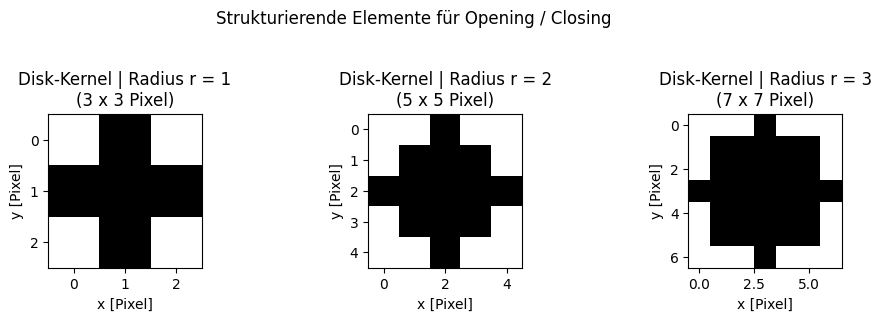

```python
from skimage.morphology import disk

fig, axes = plt.subplots(1, 3, figsize=(10, 3))
for ax, r in zip(axes, [1, 2, 3]):
    selem = disk(r)
    ax.imshow(selem, cmap="gray_r", vmin=0, vmax=1)
    ax.set_title(
        f"Disk-Kernel | Radius r = {r}\n" f"({selem.shape[0]} x {selem.shape[1]} Pixel)"
    )
    ax.set_xlabel("x [Pixel]")
    ax.set_ylabel("y [Pixel]")
plt.suptitle("Strukturierende Elemente für Opening / Closing", y=1.05)
plt.tight_layout()
plt.show()
```

### 1.2.3 Skeletonisierung

**Methode:** `skimage.morphology.skeletonize` (thinning-basierter Algorithmus, liefert einen 1-Pixel breiten Skelettgraph).

**Zielobjekt:** Die grösste Connected Component im Kartenausschnitt (maximale Pixelfläche nach morphologischer Bereinigung). Diese Wahl garantiert, dass ein vollständiges Symbol skeletonisiert wird und kein Rauschfragment oder Randausschnitt. Die Auswahl erfolgt automatisch über `skimage.measure.regionprops` nach der Labelisierung.

**Metrik:** Skeleton Pixel Count – die Gesamtzahl der Vordergrundpixel im Skelettbild – dient als Mass für die Konturkomplexität des Symbols. Ein Balken hat ein einfaches, lineares Skelett (wenige Pixel); eine Welle ein gewundenes Skelett (mehr Pixel). Diese Metrik wird in Tag 14 für den Konfigurationsvergleich herangezogen.

### 1.2.4 Objekteigenschaften

Drei geometrische Eigenschaften werden pro Connected Component extrahiert (`skimage.measure.regionprops`):

| Eigenschaft | Scikit-image Attribut | Einheit | Relevanz für SET |
| --- | --- | --- | --- |
| Fläche | `area` | px² | Symbolanzahl: grössere Symbole bei 1x-Karten als bei 3x |
| Umfang | `perimeter` | px | Formkomplexität: Welle > Raute > Balken |
| Exzentrizität | `eccentricity` | dimensionslos [0, 1] | Elongiertheit: Balken/Welle hoch, Raute mittel |

Exzentrizität = 0 entspricht einem Kreis, Exzentrizität = 1 einer Linie. Die Kombination von Fläche und Exzentrizität kann Symbole voneinander unterscheiden und ist ein erster Schritt zur Formklassifikation.

### 1.2.5 Schlüsselparameter

[output not shown]

### 1.2.6 Konfigurationsübersicht

| Konfiguration | `kernel_size` | `use_closing` | `min_area_px` | Rationale |
| --- | --- | --- | --- | --- |
| Baseline | 2 | False | 500 | Otsu + leichtes Opening; kein Closing; konservative Mindestfläche |
| Variation 1 | 2 | True | 500 | wie Baseline + Closing; verbessert “halb”-Symbole |
| Variation 2 | 3 | True | 200 | grösserer Kernel; kleineres min_area; robuster bei schwachen Symbolen |

```python
configs = [
    {"name": "Baseline", "kernel_size": 2, "use_closing": False, "min_area_px": 500},
    {"name": "Variation 1", "kernel_size": 2, "use_closing": True, "min_area_px": 500},
    {"name": "Variation 2", "kernel_size": 3, "use_closing": True, "min_area_px": 200},
]

print(
    f"{'Konfiguration':<14} {'kernel_size':>12} {'use_closing':>12} {'min_area_px':>12}"
)
print("-" * 52)
for c in configs:
    print(
        f"{c['name']:<14} {c['kernel_size']:>12} {str(c['use_closing']):>12} {c['min_area_px']:>12}"
    )
```

```
Konfiguration   kernel_size  use_closing  min_area_px
----------------------------------------------------
Baseline                  2        False          500
Variation 1               2         True          500
Variation 2               3         True          200
```

## 1.3 Tag 13 – Technische Implementierung

Tag 13 implementiert die in Tag 12 definierte Segmentierungspipeline vollständig und nachvollziehbar für alle drei Konfigurationen. Jeder Schritt wird mit Zwischenresultaten visualisiert. Die Verarbeitungssequenz ist: (1) Otsu-Binarisierung, (2) Opening, (3) Mindestflächen-Filter, (4) optionales Closing, (5) Connected Components & Objekteigenschaften, (6) Skeletonisierung des grössten Objekts. Keine quantitative Evaluation oder Interpretation – diese folgen an Tag 14 und 15.

### 1.3.1 Schritt 0: Setup & Daten

```
Kartenausschnitt: 867 x 484 Pixel
Intensitätsbereich: [1, 255] | Mittelwert: 185.9

Konfiguration   kernel_size  use_closing  min_area_px
----------------------------------------------------
Baseline                  2        False          500
Variation 1               2         True          500
Variation 2               3         True          200
```

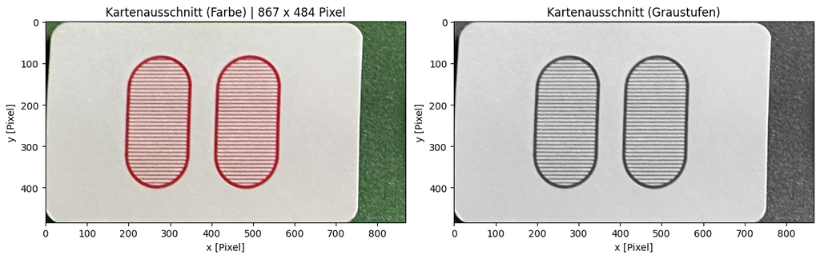

```python
from pathlib import Path
import numpy as np
import matplotlib.pyplot as plt
from PIL import Image
from skimage.filters import threshold_otsu
from skimage.morphology import disk, opening, closing, skeletonize
from skimage.measure import label, regionprops
from skimage.color import label2rgb

IMG_PATH = Path("..") / "data" / "IMG_6947.JPG"
img_pil = Image.open(IMG_PATH)
img = np.array(img_pil)
img_gray = np.array(img_pil.convert("L"))
H, W = img_gray.shape

# Kartenausschnitt (obere linke Karte, identisch mit Tag 11/12)
y0, y1 = int(0.074 * H), int(0.234 * H)
x0, x1 = int(0.173 * W), int(0.388 * W)
card_crop = img[y0:y1, x0:x1]
card_gray = img_gray[y0:y1, x0:x1]

configs = [
    {"name": "Baseline", "kernel_size": 2, "use_closing": False, "min_area_px": 500},
    {"name": "Variation 1", "kernel_size": 2, "use_closing": True, "min_area_px": 500},
    {"name": "Variation 2", "kernel_size": 3, "use_closing": True, "min_area_px": 200},
]

print(f"Kartenausschnitt: {card_gray.shape[1]} x {card_gray.shape[0]} Pixel")
print(
    f"Intensitätsbereich: [{card_gray.min()}, {card_gray.max()}] | Mittelwert: {card_gray.mean():.1f}"
)
print()
print(
    f"{'Konfiguration':<14} {'kernel_size':>12} {'use_closing':>12} {'min_area_px':>12}"
)
print("-" * 52)
for c in configs:
    print(
        f"{c['name']:<14} {c['kernel_size']:>12} {str(c['use_closing']):>12} {c['min_area_px']:>12}"
    )

fig, axes = plt.subplots(1, 2, figsize=(12, 5))
axes[0].imshow(card_crop)
axes[0].set_title(
    f"Kartenausschnitt (Farbe) | {card_gray.shape[1]} x {card_gray.shape[0]} Pixel"
)
axes[0].set_xlabel("x [Pixel]")
axes[0].set_ylabel("y [Pixel]")
axes[1].imshow(card_gray, cmap="gray")
axes[1].set_title("Kartenausschnitt (Graustufen)")
axes[1].set_xlabel("x [Pixel]")
axes[1].set_ylabel("y [Pixel]")
plt.tight_layout()
plt.show()
```

### 1.3.2 Schritt 1: Binarisierung (Otsu-Schwellenwert)

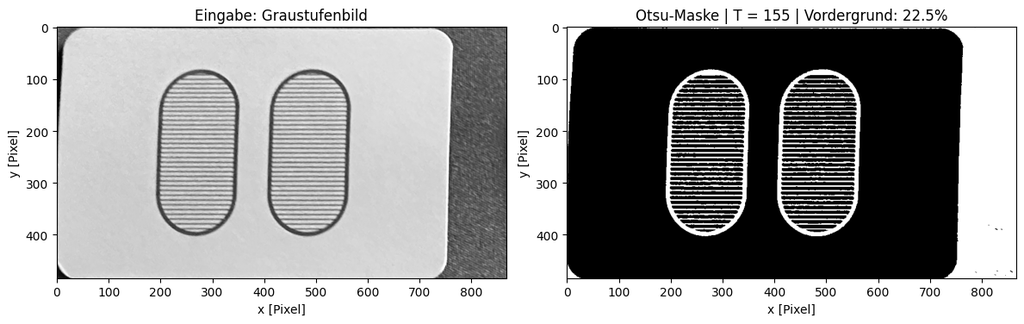

```
Otsu-Schwellenwert: T = 155
Vordergrundpixel: 94369 (22.5%)
```

```python
t_otsu = threshold_otsu(card_gray)
mask_raw = card_gray < t_otsu

fig, axes = plt.subplots(1, 2, figsize=(12, 5))
axes[0].imshow(card_gray, cmap="gray")
axes[0].set_title("Eingabe: Graustufenbild")
axes[0].set_xlabel("x [Pixel]")
axes[0].set_ylabel("y [Pixel]")
axes[1].imshow(mask_raw, cmap="gray")
axes[1].set_title(
    f"Otsu-Maske | T = {t_otsu} | Vordergrund: {mask_raw.mean()*100:.1f}%"
)
axes[1].set_xlabel("x [Pixel]")
axes[1].set_ylabel("y [Pixel]")
plt.tight_layout()
plt.show()

print(f"Otsu-Schwellenwert: T = {t_otsu}")
print(f"Vordergrundpixel: {mask_raw.sum()} ({mask_raw.mean()*100:.1f}%)")
```

### 1.3.3 Schritte 2-4: Morphologische Bereinigung

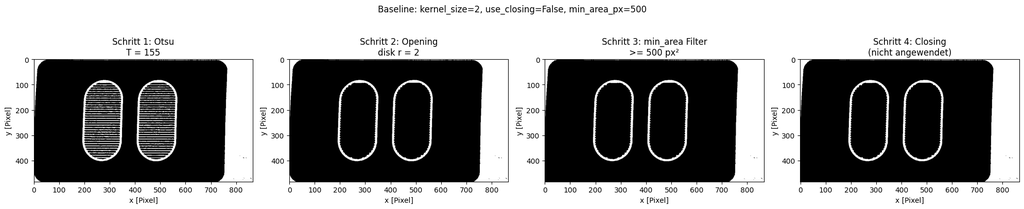

```python
def apply_pipeline(
    mask, kernel_size, use_closing, min_area_px, return_intermediate=False
):
    selem = disk(kernel_size)

    # Schritt 2: Opening
    mask_opened = opening(mask, selem)

    # Schritt 3: Mindestflächen-Filter
    lbl_tmp = label(mask_opened)
    mask_filtered = np.zeros_like(mask_opened)
    for p in regionprops(lbl_tmp):
        if p.area >= min_area_px:
            mask_filtered[lbl_tmp == p.label] = True

    # Schritt 4: Optionales Closing
    mask_final = closing(mask_filtered, selem) if use_closing else mask_filtered

    if return_intermediate:
        return mask_opened, mask_filtered, mask_final
    return mask_final


# Zwischenresultate für Baseline (Traceability)
cfg0 = configs[0]
m_opened, m_filtered, m_final_b = apply_pipeline(
    mask_raw,
    cfg0["kernel_size"],
    cfg0["use_closing"],
    cfg0["min_area_px"],
    return_intermediate=True,
)

fig, axes = plt.subplots(1, 4, figsize=(20, 4))
data = [
    (mask_raw, f"Schritt 1: Otsu\nT = {t_otsu}"),
    (m_opened, f"Schritt 2: Opening\ndisk r = {cfg0['kernel_size']}"),
    (m_filtered, f"Schritt 3: min_area Filter\n>= {cfg0['min_area_px']} px²"),
    (m_final_b, f"Schritt 4: Closing\n(nicht angewendet)"),
]
for ax, (mask, title) in zip(axes, data):
    ax.imshow(mask, cmap="gray")
    ax.set_title(title)
    ax.set_xlabel("x [Pixel]")
    ax.set_ylabel("y [Pixel]")
plt.suptitle(
    f"Baseline: kernel_size={cfg0['kernel_size']}, "
    f"use_closing={cfg0['use_closing']}, min_area_px={cfg0['min_area_px']}",
    y=1.02,
)
plt.tight_layout()
plt.show()
```

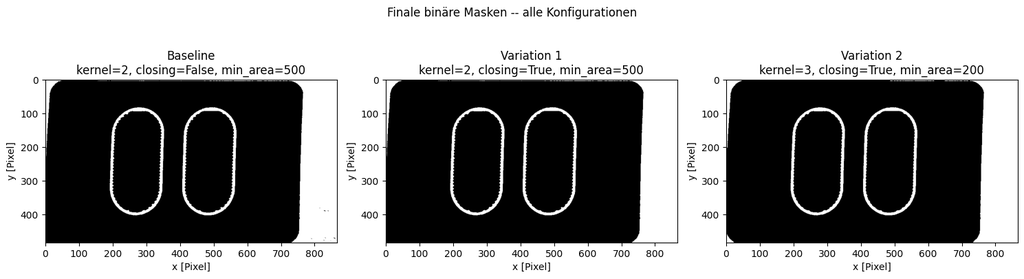

```python
# Alle drei Konfigurationen ausfuehren
final_masks = [
    apply_pipeline(mask_raw, c["kernel_size"], c["use_closing"], c["min_area_px"])
    for c in configs
]

fig, axes = plt.subplots(1, 3, figsize=(15, 4))
for ax, cfg, m in zip(axes, configs, final_masks):
    ax.imshow(m, cmap="gray")
    ax.set_title(
        f"{cfg['name']}\n"
        f"kernel={cfg['kernel_size']}, closing={cfg['use_closing']}, min_area={cfg['min_area_px']}"
    )
    ax.set_xlabel("x [Pixel]")
    ax.set_ylabel("y [Pixel]")
plt.suptitle("Finale binäre Masken -- alle Konfigurationen", y=1.02)
plt.tight_layout()
plt.show()
```

### 1.3.4 Schritt 5: Connected Components & Objektzählung

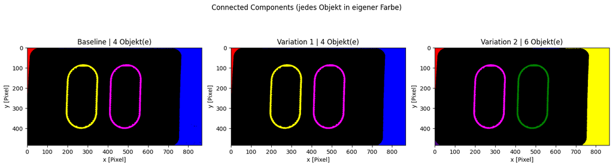

```
Objektzählung:
  Baseline: 4 Objekt(e)
  Variation 1: 4 Objekt(e)
  Variation 2: 6 Objekt(e)
```

```python
labeled_masks = [label(m) for m in final_masks]

fig, axes = plt.subplots(1, 3, figsize=(15, 4))
for ax, cfg, lbl in zip(axes, configs, labeled_masks):
    ax.imshow(label2rgb(lbl, bg_label=0))
    ax.set_title(f"{cfg['name']} | {lbl.max()} Objekt(e)")
    ax.set_xlabel("x [Pixel]")
    ax.set_ylabel("y [Pixel]")
plt.suptitle("Connected Components (jedes Objekt in eigener Farbe)", y=1.02)
plt.tight_layout()
plt.show()

print("Objektzählung:")
for cfg, lbl in zip(configs, labeled_masks):
    print(f"  {cfg['name']}: {lbl.max()} Objekt(e)")
```

### 1.3.5 Schritt 6: Objekteigenschaften (Fläche, Umfang, Exzentrizität)

```
--- Baseline ---
  Objekt    Flaeche [px²]  Umfang [px]    Exzentrizität
--------------------------------------------------------
       1             2429        537.5            0.993
       2            55523       2542.9            0.860
       3             6986       1785.4            0.810
       4             6906       1775.1            0.808

--- Variation 1 ---
  Objekt    Flaeche [px²]  Umfang [px]    Exzentrizität
--------------------------------------------------------
       1             2431        536.3            0.993
       2            55561       2455.3            0.860
       3             7013       1773.6            0.811
       4             6927       1764.1            0.808

--- Variation 2 ---
  Objekt    Flaeche [px²]  Umfang [px]    Exzentrizität
--------------------------------------------------------
       1             2347        478.2            0.991
       2              501        277.8            1.000
       3            53951       1449.8            0.972
       4             6882       1740.7            0.812
       5             6799       1724.9            0.809
       6              288         81.0            0.844
```

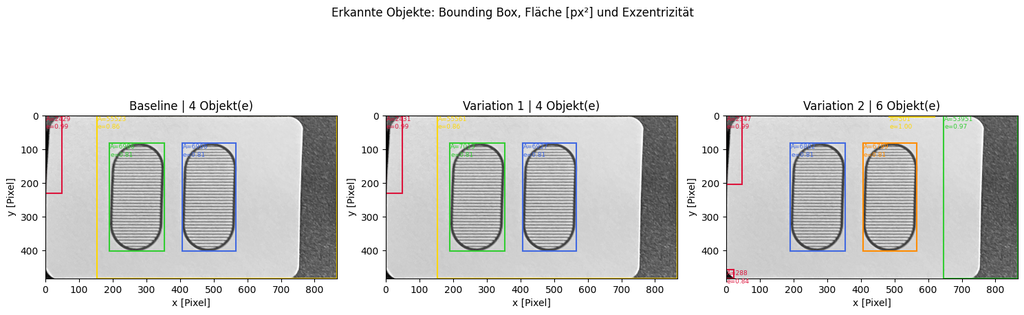

```python
import matplotlib.patches as mpatches

# Tabelle: Objekteigenschaften pro Konfiguration
for cfg, lbl in zip(configs, labeled_masks):
    props = regionprops(lbl)
    print(f"--- {cfg['name']} ---")
    print(
        f"{'Objekt':>8} {'Flaeche [px\u00b2]':>16} {'Umfang [px]':>12} {'Exzentrizität':>16}"
    )
    print("-" * 56)
    for p in props:
        print(
            f"{p.label:>8} {p.area:>16.0f} {p.perimeter:>12.1f} {p.eccentricity:>16.3f}"
        )
    print()

# Visualisierung: Bounding Boxes der erkannten Objekte auf dem Graustufenbild
_colors = ["crimson", "gold", "limegreen", "royalblue", "darkorange"]
fig, axes = plt.subplots(1, 3, figsize=(15, 5))
for ax, cfg, lbl in zip(axes, configs, labeled_masks):
    ax.imshow(card_gray, cmap="gray")
    for i, p in enumerate(regionprops(lbl)):
        y_min, x_min, y_max, x_max = p.bbox
        ax.add_patch(
            mpatches.Rectangle(
                (x_min, y_min),
                x_max - x_min,
                y_max - y_min,
                linewidth=1.5,
                edgecolor=_colors[i % len(_colors)],
                facecolor="none",
            )
        )
        ax.text(
            x_min + 2,
            y_min + 2,
            f"A={p.area:.0f}\ne={p.eccentricity:.2f}",
            color=_colors[i % len(_colors)],
            fontsize=6.5,
            va="top",
            linespacing=1.3,
        )
    ax.set_title(f"{cfg['name']} | {lbl.max()} Objekt(e)")
    ax.set_xlabel("x [Pixel]")
    ax.set_ylabel("y [Pixel]")
plt.suptitle(
    "Erkannte Objekte: Bounding Box, Fläche [px\u00b2] und Exzentrizität", y=1.02
)
plt.tight_layout()
plt.show()
```

### 1.3.6 Schritt 7: Skeletonisierung des grössten Symbols

Der Kartenausschnitt enthält neben den eigentlichen Symbolen eine grossflächige Randregion (Kartenborde + Spielmatte), die durch den dunklen Hintergrund ebenfalls als Vordergrund klassifiziert wird. Diese Randkomponente belegt typischerweise ca. 13 % der Ausschnittsfläche, während die eigentlichen Symbole ca. 1–3 % belegen. Eine Obergrenze von 10 % der Ausschnittsfläche trennt beide Gruppen zuverlässig: Komponenten oberhalb dieser Grenze werden als Artefakt ausgeschlossen; die grösste verbleibende Komponente entspricht dem Symbol mit der grössten Ausdehnung. Die quantitative Bewertung des Skeleton Pixel Count erfolgt an Tag†14.

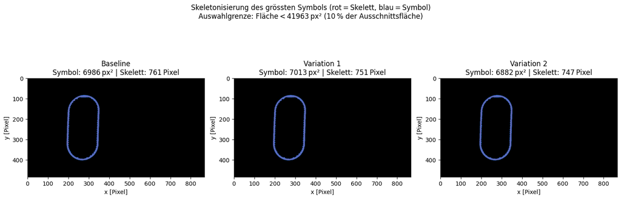

```
Kartenausschnittsfläche: 419628 px² | Symbolgrenze: < 41963 px²
Skeleton Pixel Count:
  Baseline: 761 Pixel
  Variation 1: 751 Pixel
  Variation 2: 747 Pixel
```

```python
card_area = card_gray.size  # Gesamtpixelanzahl des Kartenausschnitts
max_symbol_area = 0.10 * card_area  # Grenzwert: Symbole < 10 % (Randkomponente > 13 %)

fig, axes = plt.subplots(1, 3, figsize=(15, 5))
skel_counts = {}

for ax, cfg, lbl in zip(axes, configs, labeled_masks):
    props = regionprops(lbl)
    symbols = [p for p in props if p.area < max_symbol_area]

    if not symbols:
        ax.set_title(f"{cfg['name']}\nKein Symbol gefunden")
        skel_counts[cfg["name"]] = 0
        continue

    target = max(symbols, key=lambda p: p.area)  # grösstes Symbol
    obj_mask = lbl == target.label
    skeleton = skeletonize(obj_mask)
    skel_count = int(skeleton.sum())
    skel_counts[cfg["name"]] = skel_count

    overlay = np.zeros((*obj_mask.shape, 3), dtype=float)
    overlay[obj_mask] = [0.25, 0.45, 0.85]
    overlay[skeleton] = [0.95, 0.25, 0.15]

    ax.imshow(overlay)
    ax.set_title(
        f"{cfg['name']}\n"
        f"Symbol: {target.area:.0f} px² | Skelett: {skel_count} Pixel"
    )
    ax.set_xlabel("x [Pixel]")
    ax.set_ylabel("y [Pixel]")

plt.suptitle(
    "Skeletonisierung des grössten Symbols (rot = Skelett, blau = Symbol)\n"
    f"Auswahlgrenze: Fläche < {max_symbol_area:.0f} px² (10 % der Ausschnittsfläche)",
    y=1.04,
)
plt.tight_layout()
plt.show()

print(
    f"Kartenausschnittsfläche: {card_area} px² | Symbolgrenze: < {max_symbol_area:.0f} px²"
)
print("Skeleton Pixel Count:")
for name, count in skel_counts.items():
    print(f"  {name}: {count} Pixel")
```

## 1.4 Tag 14 – Evaluation

Tag 14 bewertet die Segmentierungsergebnisse aus Tag 13 quantitativ. Ein Segmentierungsmass wird konsistent über alle drei Konfigurationen angewendet. Zusätzlich werden deskriptive Statistiken der Objekteigenschaften (Fläche, Umfang, Exzentrizität) pro Konfiguration berechnet und direkt mit der Baseline verglichen. Keine neue Implementierung und keine inhaltliche Interpretation – diese folgen an Tag 15.

### 1.4.1 Setup: Pipeline-Wiederherstellung

```python
from pathlib import Path
import numpy as np
import matplotlib.pyplot as plt
import matplotlib.patches as mpatches
from PIL import Image
from skimage.filters import threshold_otsu
from skimage.morphology import disk, opening, closing
from skimage.measure import label, regionprops

IMG_PATH = Path("..") / "data" / "IMG_6947.JPG"
img_pil = Image.open(IMG_PATH)
img_gray = np.array(img_pil.convert("L"))
H, W = img_gray.shape

y0, y1 = int(0.074 * H), int(0.234 * H)
x0, x1 = int(0.173 * W), int(0.388 * W)
card_gray = img_gray[y0:y1, x0:x1]
card_area = card_gray.size
max_symbol_area = 0.10 * card_area  # Symbole < 10 % der Ausschnittsfläche

configs = [
    {"name": "Baseline", "kernel_size": 2, "use_closing": False, "min_area_px": 500},
    {"name": "Variation 1", "kernel_size": 2, "use_closing": True, "min_area_px": 500},
    {"name": "Variation 2", "kernel_size": 3, "use_closing": True, "min_area_px": 200},
]

t_otsu = threshold_otsu(card_gray)
mask_raw = card_gray < t_otsu


def apply_pipeline(mask, kernel_size, use_closing, min_area_px):
    selem = disk(kernel_size)
    m = opening(mask, selem)
    lbl_tmp = label(m)
    filtered = np.zeros_like(m)
    for p in regionprops(lbl_tmp):
        if p.area >= min_area_px:
            filtered[lbl_tmp == p.label] = True
    return closing(filtered, selem) if use_closing else filtered


final_masks = [
    apply_pipeline(mask_raw, c["kernel_size"], c["use_closing"], c["min_area_px"])
    for c in configs
]
labeled_masks = [label(m) for m in final_masks]

print(
    f"Kartenausschnitt: {card_gray.shape[1]} x {card_gray.shape[0]} px | "
    f"Otsu T = {t_otsu} | Symbolgrenze < {max_symbol_area:.0f} px\u00b2"
)
print(f"Konfigurationen: {[c['name'] for c in configs]}")
```

```
Kartenausschnitt: 867 x 484 px | Otsu T = 155 | Symbolgrenze < 41963 px²
Konfigurationen: ['Baseline', 'Variation 1', 'Variation 2']
```

### 1.4.2 Segmentierungsmass: Dice-Koeffizient

**Begründung:** Da keine manuell annotierte Ground-Truth-Maske vorliegt, dient die Baseline-Maske als Referenz. Der Dice-Koeffizient quantifiziert direkt, wie stark eine Parametervariante die Segmentierungsentscheidungen gegenüber der Baseline verändert. Er ist normiert, symmetrisch und in der Bildverarbeitungsliteratur etabliert. Im SET-Anwendungsfall ist ein Dice nahe 1 erwünscht, wenn die Variationen nur gezielte Korrekturen bewirken; ein deutlich niedrigerer Dice würde auf substantielle Unterschiede bei der Symbolisolation hinweisen.

```python
def dice(a, b):
    return 2 * (a & b).sum() / (a.sum() + b.sum())


baseline = final_masks[0]
dice_vals = [dice(baseline, m) for m in final_masks]

print(
    f"{'Konfiguration':<14} {'Dice vs. Baseline':>18} {'\u0394Dice':>10} "
    f"{'Vordergrund [px\u00b2]':>20} {'\u0394 Vordergrund [px\u00b2]':>22}"
)
print("-" * 86)
base_fg = baseline.sum()
for cfg, d, m in zip(configs, dice_vals, final_masks):
    fg = m.sum()
    delta_d = d - dice_vals[0]
    delta_fg = int(fg) - int(base_fg)
    delta_d_str = f"{delta_d:+.4f}" if delta_d != 0 else "--"
    delta_fg_str = f"{delta_fg:+d}" if delta_fg != 0 else "--"
    print(
        f"{cfg['name']:<14} {d:>18.4f} {delta_d_str:>10} {int(fg):>20} {delta_fg_str:>22}"
    )
```

```
Konfiguration   Dice vs. Baseline      ΔDice    Vordergrund [px²]    Δ Vordergrund [px²]
--------------------------------------------------------------------------------------
Baseline                   1.0000         --                71844                     --
Variation 1                0.9994    -0.0006                71932                    +88
Variation 2                0.9866    -0.0134                70768                  -1076
```

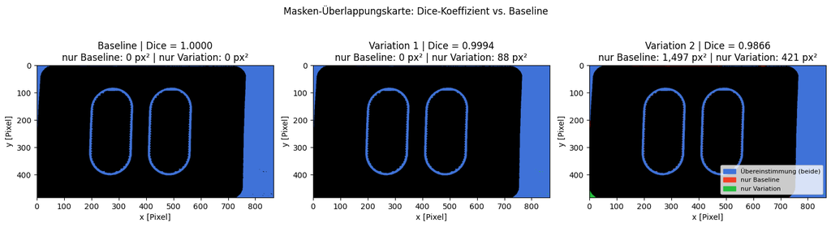

```python
# Masken-Überlappungskarte: Baseline als Referenz
fig, axes = plt.subplots(1, 3, figsize=(15, 4))
for ax, cfg, m, d in zip(axes, configs, final_masks, dice_vals):
    only_base = baseline & ~m
    only_var = ~baseline & m
    agree = baseline & m

    overlay = np.zeros((*m.shape, 3), dtype=float)
    overlay[agree] = [0.25, 0.45, 0.85]  # blau: Übereinstimmung
    overlay[only_base] = [0.95, 0.25, 0.15]  # rot: nur Baseline
    overlay[only_var] = [0.15, 0.75, 0.25]  # grün: nur Variation

    ax.imshow(overlay)
    ax.set_title(
        f"{cfg['name']} | Dice = {d:.4f}\n"
        f"nur Baseline: {only_base.sum():,} px\u00b2 | "
        f"nur Variation: {only_var.sum():,} px\u00b2"
    )
    ax.set_xlabel("x [Pixel]")
    ax.set_ylabel("y [Pixel]")

legend_handles = [
    mpatches.Patch(color=[0.25, 0.45, 0.85], label="Übereinstimmung (beide)"),
    mpatches.Patch(color=[0.95, 0.25, 0.15], label="nur Baseline"),
    mpatches.Patch(color=[0.15, 0.75, 0.25], label="nur Variation"),
]
axes[2].legend(handles=legend_handles, loc="lower right", fontsize=8)
plt.suptitle("Masken-Überlappungskarte: Dice-Koeffizient vs. Baseline", y=1.02)
plt.tight_layout()
plt.show()
```

### 1.4.3 Deskriptive Statistiken der Objekteigenschaften

```python
stats = {}
for cfg, lbl in zip(configs, labeled_masks):
    props = regionprops(lbl)
    cands = [p for p in props if p.area < max_symbol_area]
    areas = np.array([p.area for p in cands], dtype=float)
    perims = np.array([p.perimeter for p in cands], dtype=float)
    eccs = np.array([p.eccentricity for p in cands], dtype=float)
    stats[cfg["name"]] = {
        "n": len(cands),
        "area": areas,
        "perim": perims,
        "ecc": eccs,
    }

# Tabelle: Mittelwert ± Standardabweichung + Delta vs. Baseline
base_s = stats["Baseline"]
print(
    f"{'Konfiguration':<14} {'N':>4} "
    f"{'Fl\u00e4che \u03bc [px\u00b2]':>16} {'\u03c3':>8} {'\u0394\u03bc':>8} "
    f"{'Umfang \u03bc [px]':>14} {'\u03c3':>8} {'\u0394\u03bc':>8} "
    f"{'Exz. \u03bc':>10} {'\u03c3':>7} {'\u0394\u03bc':>8}"
)
print("-" * 115)
for name, s in stats.items():
    da = np.mean(s["area"]) - np.mean(base_s["area"])
    dp = np.mean(s["perim"]) - np.mean(base_s["perim"])
    de = np.mean(s["ecc"]) - np.mean(base_s["ecc"])
    da_s = f"{da:+.0f}" if da != 0 else "--"
    dp_s = f"{dp:+.1f}" if dp != 0 else "--"
    de_s = f"{de:+.3f}" if de != 0 else "--"
    print(
        f"{name:<14} {s['n']:>4} "
        f"{np.mean(s['area']):>16.0f} {np.std(s['area']):>8.0f} {da_s:>8} "
        f"{np.mean(s['perim']):>14.1f} {np.std(s['perim']):>8.1f} {dp_s:>8} "
        f"{np.mean(s['ecc']):>10.3f} {np.std(s['ecc']):>7.3f} {de_s:>8}"
    )
print()
print("Wertebereich pro Eigenschaft und Konfiguration:")
for name, s in stats.items():
    print(
        f"  {name}: "
        f"Fl\u00e4che [{s['area'].min():.0f}, {s['area'].max():.0f}] px\u00b2 | "
        f"Umfang [{s['perim'].min():.1f}, {s['perim'].max():.1f}] px | "
        f"Exz. [{s['ecc'].min():.3f}, {s['ecc'].max():.3f}]"
    )
```

```
Konfiguration     N   Fläche μ [px²]        σ       Δμ  Umfang μ [px]        σ       Δμ     Exz. μ       σ       Δμ
-------------------------------------------------------------------------------------------------------------------
Baseline          3             5440     2130       --         1366.0    585.9       --      0.870   0.087       --
Variation 1       3             5457     2140      +17         1358.0    581.0     -8.0      0.870   0.086   +0.000
Variation 2       5             3363     2928    -2077          860.5    723.2   -505.5      0.891   0.086   +0.021

Wertebereich pro Eigenschaft und Konfiguration:
  Baseline: Fläche [2429, 6986] px² | Umfang [537.5, 1785.4] px | Exz. [0.808, 0.993]
  Variation 1: Fläche [2431, 7013] px² | Umfang [536.3, 1773.6] px | Exz. [0.808, 0.993]
  Variation 2: Fläche [288, 6882] px² | Umfang [81.0, 1740.7] px | Exz. [0.809, 1.000]
```

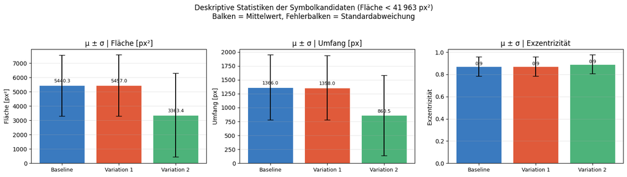

```python
props_labels = ["Fl\u00e4che [px\u00b2]", "Umfang [px]", "Exzentrizit\u00e4t"]
prop_keys = ["area", "perim", "ecc"]
cfg_names = [c["name"] for c in configs]
x = np.arange(len(cfg_names))
bar_colors = ["#3a7abf", "#e05a3a", "#4db37a"]

fig, axes = plt.subplots(1, 3, figsize=(15, 4))
for ax, key, label_str in zip(axes, prop_keys, props_labels):
    means = [np.mean(stats[n][key]) for n in cfg_names]
    stds = [np.std(stats[n][key]) for n in cfg_names]
    bars = ax.bar(
        x,
        means,
        yerr=stds,
        capsize=5,
        color=bar_colors,
        edgecolor="white",
        linewidth=0.8,
    )
    ax.set_xticks(x)
    ax.set_xticklabels(cfg_names, fontsize=9)
    ax.set_ylabel(label_str)
    ax.set_title(f"\u03bc \u00b1 \u03c3 | {label_str}")
    ax.grid(True, axis="y", alpha=0.3)
    for bar, mean in zip(bars, means):
        ax.text(
            bar.get_x() + bar.get_width() / 2,
            bar.get_height() + max(stds) * 0.05,
            f"{mean:.1f}",
            ha="center",
            va="bottom",
            fontsize=8,
        )

plt.suptitle(
    "Deskriptive Statistiken der Symbolkandidaten (Fläche < 41\u202f963 px\u00b2)\n"
    "Balken = Mittelwert, Fehlerbalken = Standardabweichung",
    y=1.04,
)
plt.tight_layout()
plt.show()
```

## 1.5 Tag 15 – Analyse & Kommunikation

Tag 15 analysiert und interpretiert die Ergebnisse aus Tag 14 im Kontext des SET-Anwendungsfalls. Der Analysetext ist in Beobachtungen, Interpretation und kritische Diskussion gegliedert (ca. 150-200 Wörter). Anschliessend folgt eine persönliche Abschlussreflexion zur Mini-Challenge (ca. 150 Wörter). Keine neuen Berechnungen oder Simulationen.

### 1.5.1 Beobachtungen

Der Dice-Koeffizient beträgt für Variation 1 (Closing=True, kernel=2) 0.9994 (ΔDice -0.0006) und für Variation 2 (kernel=3, min_area_px=200) 0.9866 (ΔDice -0.0134) relativ zur Baseline. Die Vordergrundpixelzahl ändert sich in Variation 1 kaum (+88 px²) und sinkt in Variation 2 um 1076 px². Symbolkandidaten: N = 3 für Baseline und Variation 1, N = 5 für Variation 2. Mittlere Fläche: 5440 px² (Baseline) vs. 3363 px² (Variation 2, Δμ = -2077 px²). Der Skeleton Pixel Count nimmt von 761 auf 747 Pixel ab.